# from chart v, i observe that the discounts offered tend to be lower (0 to 10) for products whose costs are in the tail ends (100 and 300) while for the non-tail-end portions (about 120-270) the discounts offered were the highest

**END: YOUR ANSWER**

### Q2.(b) Customer Analyses Dashboard (7 marks)

This dashboard is to enable the company to understand their customers better. The following are the requirements for the Customer Analyses Dashboard:

- 1. To be able to view the frequency distributions for each of the following variables in a chart and table: `Gender`, `Customer_care_calls`, `Customer_rating`
- 2. To be able to view the frequency distribution for `Customer rating` across different Gender in one table and barplot. Do you observe any difference in customer rating across females and males?
- 3. To be able to view the frequency distribution for `Cost_of_the_Products` for each gender in two separate tables and charts. Do you observe any different across females and males?

**BEGIN: YOUR ANSWER**

```r
# i)
genderFreq <- ES %>% count(Gender)
kable(genderFreq, caption = "Gender Frequency")
```

Gender Frequency

| Gender | n |
| --- | --- |
| F | 5545 |
| M | 5454 |

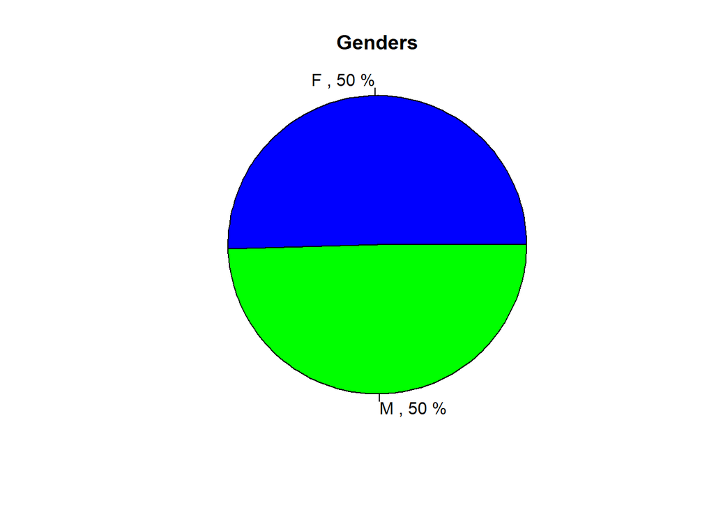

```r
slice.gender <- genderFreq$n
gender.piepercent <- 100 * round(genderFreq$n / sum(genderFreq$n), 2)
label <- genderFreq$Gender
label <- paste(label, ",", sep = " ")
label <- paste(label, gender.piepercent)
label <- paste(label, "%")

pie(slice.gender, labels = label,
    col = c("blue", "green", "red"),
    radius = 1,
    main = "Genders")
```

```r
#`Customer_care_calls`
callsFreq <- ES %>% count(Customer_care_calls)
kable(callsFreq, caption = "Customer Care Calls Frequency")
```

Customer Care Calls Frequency

| Customer_care_calls | n |
| --- | --- |
| 2 | 638 |
| 3 | 3217 |
| 4 | 3557 |
| 5 | 2328 |
| 6 | 1013 |
| 7 | 246 |

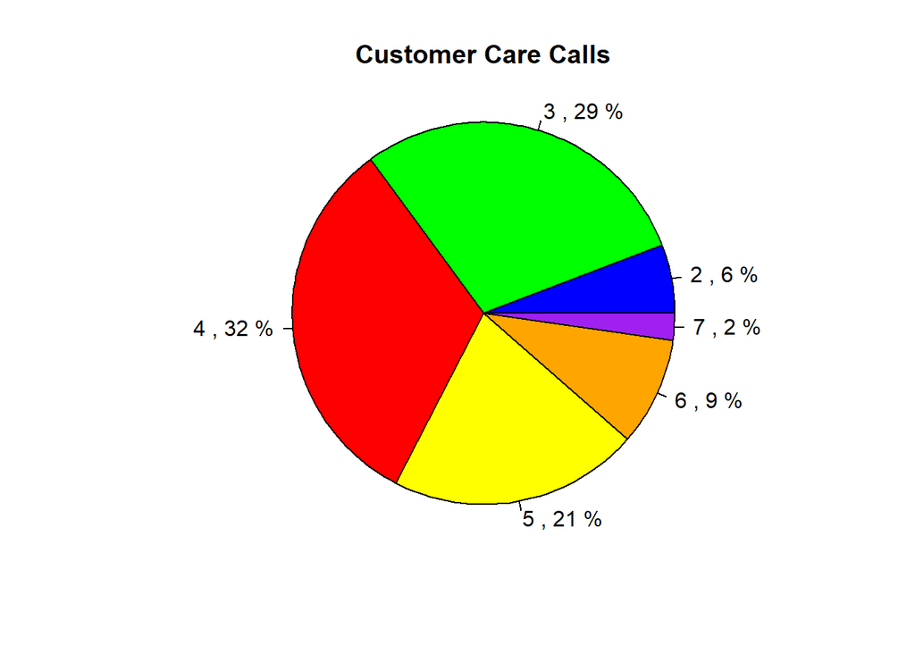

```r
slice.calls <- callsFreq$n
calls.piepercent <- 100 * round(callsFreq$n / sum(callsFreq$n), 2)
label <- callsFreq$Customer_care_calls
label <- paste(label, ",", sep = " ")
label <- paste(label, calls.piepercent)
label <- paste(label, "%")

pie(slice.calls, labels = label,
    col = c("blue", "green", "red", "yellow", "orange", "purple"),
    radius = 1,
    main = "Customer Care Calls")
```

```r
#`Customer_rating`
ratingFreq <- ES %>% count(Customer_rating)
kable(ratingFreq, caption = "Customer Rating Frequency")
```

Customer Rating Frequency

| Customer_rating | n |
| --- | --- |
| 1 | 2235 |
| 2 | 2165 |
| 3 | 2239 |
| 4 | 2189 |
| 5 | 2171 |

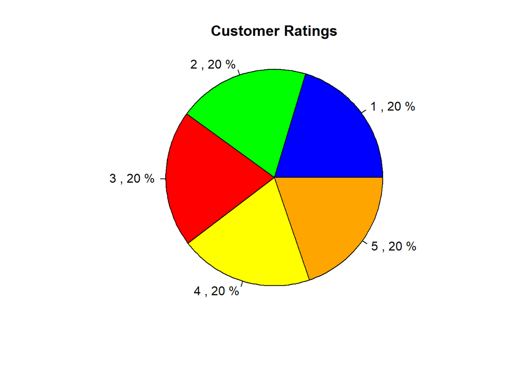

```r
slice.rating <- ratingFreq$n
rating.piepercent <- 100 * round(ratingFreq$n / sum(ratingFreq$n), 2)
label <- ratingFreq$Customer_rating
label <- paste(label, ",", sep = " ")
label <- paste(label, rating.piepercent)
label <- paste(label, "%")

pie(slice.rating, labels = label,
    col = c("blue", "green", "red", "yellow", "orange"),
    radius = 1,
    main = "Customer Ratings")
```

```r
# ii)
# create contingency table for Gender (as rows) and Customer ratings (as columns)
ES1 <- ES %>% group_by(Gender, Customer_rating) %>% tally()
ES1.spread <- ES1 %>% spread(key = Customer_rating, value = n)
kable(ES1.spread, caption = "Contingency table for Gender and Customer Rating")
```

Contingency table for Gender and Customer Rating

| Gender | 1 | 2 | 3 | 4 | 5 |
| --- | --- | --- | --- | --- | --- |
| F | 1149 | 1062 | 1143 | 1096 | 1095 |
| M | 1086 | 1103 | 1096 | 1093 | 1076 |